# raw2flux

Camille Minaudo

2024-02-08

# Setting Up: Loading Libraries and Defining Paths

## Load packages and source functions

Before loading all the packages, we must have installed all the dependencies. You run this script to make sure that you have all dependencies installed.

```r
rm(list = ls()) # clear workspace
cat("/014") # clear console
```

```
## /014
```

```r
# ---- packages ----
library(tidyverse)
library(readxl)
library(lubridate)
library(zoo)
library(ggplot2)
library(grid)
library(egg)
library(GoFluxYourself)
require(dplyr)
require(purrr)
require(msm)
require(tools)
require(pbapply)

repo_root <- dirname(dirname(rstudioapi::getSourceEditorContext()$path))
files.sources = list.files(path = paste0(repo_root,"/functions"), full.names = T)
for (f in files.sources){source(f)}
```

## Set paths to directories and specify plot option

The idea here is to save the information about where the files we want to import are located and where we will save the results we obtain, so we can call them later during the script. The structure of the repository should not be changed. Data in the data folder can however be changed as long as the data structure remains the same as in the example provided here.

```r
datapath <- paste0(repo_root,"/data")
rawdatapath <- paste0(datapath,"/raw_data/RAW Data Picarro")
fieldsheetpath <- paste0(datapath,"/fieldsheets")
# corrfieldsheetpath <- paste0(datapath,"/GHG/Processed data/corrected_fieldsheets")
loggerspath <- paste0(datapath,"/raw_data/RAW Data Logger")
plots_path <- paste0(repo_root,"/results/plots")
results_path <- paste0(repo_root,"/results/processed")

# set doPlot if you want timeseries of incubations to be plotted and saved
doPlot <- T
```

# Import data

We’re going to import all the field sheets we have and the raw data provided by the our device.

## Read fieldsheets in fieldsheet path

```r
# list all fieldsheets available in the folder
myfieldsheets_list <- list.files(fieldsheetpath, pattern = "-Fieldsheet-GHG.xlsx", all.files = T, full.names = T, recursive = T)
# Read all fieldsheets and put them in a single dataframe
fieldsheet <- read_GHG_fieldsheets(myfieldsheets_list)
```

## Import and store RAW measurements to RData

```r
data_folders <- list.dirs(rawdatapath, full.names = T, recursive = F)
r <- grep(pattern = "RData",x=data_folders)
if(length(r)>0){data_folders <- data_folders[-r]}

message("Here is the list of data folders in here:")
```

```
## Here is the list of data folders in here:
```

```r
print(data_folders)
```

```
## [1] "/home/jorge/Documentos/GitHub_projects/picarroprocessing/data/raw_data/RAW Data Picarro/S1-VA-P2"
```

```r
for (data_folder in data_folders){
  setwd(data_folder)
  subsite = basename(data_folder)
  message(paste0("processing folder ",basename(data_folder)))
  import2RData(path = data_folder, instrument = "G2508",
               date.format = "ymd", timezone = 'UTC')

  # load all these R.Data into a single dataframe
  file_list <- list.files(path = paste(data_folder,"/RData",sep=""), full.names = T)
  isF <- T
  for(i in seq_along(file_list)){
    load(file_list[i])
    if(isF){
      isF <- F
      mydata_imp <- data.raw
    } else {
      mydata_imp <- rbind(mydata_imp, data.raw)
    }
    rm(data.raw)
  }

  # get read of possible duplicated data
  is_duplicate <- duplicated(mydata_imp$POSIX.time)
  mydata <- mydata_imp[!is_duplicate,]

  # creating a folder where to put this data
  dir.create(file.path(results_path, subsite))
  setwd(file.path(results_path, subsite))

  # save this dataframe as a new RData file
  save(mydata, file = paste0("data_",subsite,".RData"))
}
```

```
## processing folder S1-VA-P2
```

```
## NOMAD-20231109-092812Z-DataLog_User_Minimal saved as G2508_NOMAD-20231109-092812Z-DataLog_User_Minimal_imp.RData in RData folder, in working directory
```

```
## NOMAD-20231109-102816Z-DataLog_User_Minimal saved as G2508_NOMAD-20231109-102816Z-DataLog_User_Minimal_imp.RData in RData folder, in working directory
```

```
## NOMAD-20231109-112821Z-DataLog_User_Minimal saved as G2508_NOMAD-20231109-112821Z-DataLog_User_Minimal_imp.RData in RData folder, in working directory
```

```
## NOMAD-20231109-122825Z-DataLog_User_Minimal saved as G2508_NOMAD-20231109-122825Z-DataLog_User_Minimal_imp.RData in RData folder, in working directory
```

```
## NOMAD-20231109-132830Z-DataLog_User_Minimal saved as G2508_NOMAD-20231109-132830Z-DataLog_User_Minimal_imp.RData in RData folder, in working directory
```

```r
head(mydata)
```

```
##   ALARM_STATUS CavityPressure CavityTemp       DATE         TIME CO2dry_ppm
## 1            0       737.7143   26.72274 2023-11-09 09:28:08.805   421.0762
## 2            0       737.7293   26.72466 2023-11-09 09:28:09.907   420.4662
## 3            0       737.7573   26.72567 2023-11-09 09:28:10.903   420.1834
## 4            0       737.7451   26.72567 2023-11-09 09:28:11.973   418.4182
## 5            0       737.7078   26.72567 2023-11-09 09:28:13.006   418.6427
## 6            0       737.7454   26.72626 2023-11-09 09:28:14.138   418.2713
##    H2O_ppm CH4dry_ppb          POSIX.time
## 1 1633.908   2011.357 2023-11-09 09:28:08
## 2 1633.920   2011.392 2023-11-09 09:28:09
## 3 1574.996   2009.898 2023-11-09 09:28:10
## 4 1574.996   2009.898 2023-11-09 09:28:11
## 5 1621.404   2009.621 2023-11-09 09:28:13
## 6 1621.408   2009.632 2023-11-09 09:28:14
```

# Data Correction and Auxilary Information (dataloggers)

## Correct fieldsheet times based on “incubation map”

Often we find discrepancies between the time we note on the field sheet and the time recorded after incubating with the equipment. Therefore, we must correct this to avoid errors.

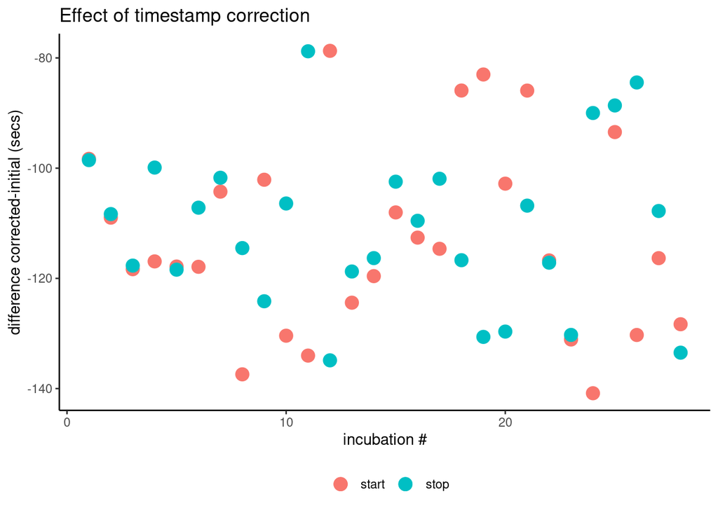

```r
read_map_incubations <- function(path2folder){

  my_maps_filenames <- list.files(data_folder, pattern = ".csv", all.files = T, full.names = T, recursive = F)
  isF <- T
  for(my_maps_filename in my_maps_filenames){

    map_incubations_temp <- read.csv(file = my_maps_filename,
                                     header = T)
    map_incubations_temp <- map_incubations_temp[map_incubations_temp$Species ==  "CH4",]

    if(isF){
      isF <- F
      map_incubations <- map_incubations_temp
    } else {
      map_incubations <- rbind(map_incubations, map_incubations_temp)
    }
  }

  map_incubations <- data.frame(subsite = basename(path2folder),
                                plot = map_incubations$Comment,
                                time_code = map_incubations$Time.Code,
                                start = map_incubations$start_fit,
                                stop = map_incubations$end_fit)

  return(map_incubations)
}


# read all the csv files in data_folder, and group into a single one
map_incubations <- read_map_incubations(path2folder = rawdatapath)


# check the closest incubation in map_incubations for each row in fieldsheet.
# if more than 3 minutes apart, we consider the row in map_incubations out of sampling
corresponding_row <- NA*fieldsheet$plot_id

for (i in seq_along(fieldsheet$plot_id)){
  ind <- which.min(abs(fieldsheet$unix_start[i] - map_incubations$start))
  if(abs(fieldsheet$unix_start[i] - map_incubations$start[ind])<3*60){corresponding_row[i] <- ind}
}
corresponding_row <- corresponding_row[!is.na(corresponding_row)]
map_incubations <- map_incubations[corresponding_row, ]

if(dim(map_incubations)[1] != dim(fieldsheet)[1]){
  fieldsheet <- fieldsheet[seq_along(corresponding_row),]
}

fieldsheet$start_time <- format(as.POSIXct(fieldsheet$start_time, tz = 'utc', format = "%T"), "%H:%M:%S")
fieldsheet$end_time <- format(as.POSIXct(fieldsheet$end_time, tz = 'utc', format = "%T"), "%H:%M:%S")

fieldsheet$unix_start_corrected <- map_incubations$start
fieldsheet$unix_stop_corrected <- map_incubations$stop

fieldsheet$timestamp_start <- as.POSIXct(fieldsheet$unix_start_corrected, tz = "UTC", origin = "1970-01-01")
fieldsheet$timestamp_stop <- as.POSIXct(fieldsheet$unix_stop_corrected, tz = "UTC", origin = "1970-01-01")

fieldsheet$start_time_corrected <- strftime(fieldsheet$timestamp_start, format="%H:%M:%S", tz = 'utc')
fieldsheet$end_time_corrected <- strftime(fieldsheet$timestamp_stop, format="%H:%M:%S", tz = 'utc')

# setwd(paste0(results_path,"/corrected_fieldsheets"))
f_name <- paste0(results_path,"/corrected_fieldsheets/",subsite,"-Fieldsheet-GHG_corrected.csv")
write.csv(file = f_name, x = fieldsheet, row.names = F)

fieldsheet$incubationNum <- seq_along(fieldsheet$plot_id)
ggplot(fieldsheet)+
  geom_point(aes(incubationNum, unix_start_corrected-unix_start, colour = "start"), size=4)+
  geom_point(aes(incubationNum, unix_stop_corrected-unix_stop, colour = "stop"), size=4)+
  xlab("incubation #")+ylab("difference corrected-initial (secs)")+ggtitle("Effect of timestamp correction")+
  theme_classic()+theme(legend.title = element_blank(), legend.position = "bottom")
```

## Join loggers’ data with fieldsheet and Picarro’s data to make an auxfile

We will need this information for performing calculations later on. Just for the sake of an example, this is done here only for one subsite among all the ones found in the data folder. This entire step will be reproduced later to go through all subsites.

```r
subsites <- unique(fieldsheet$subsite)
isF_incub <- T
for (subsite in subsites[1]){
  message("Now processing ",subsite)

  corresp_fs <- fieldsheet[fieldsheet$subsite == subsite,]
  gs <- first(corresp_fs$gas_analyzer)
  corresp_fs <- fieldsheet[fieldsheet$subsite == subsite,]
  corresp_fs$unix_start <- corresp_fs$unix_start_corrected
  corresp_fs$unix_stop <- corresp_fs$unix_stop_corrected
  corresp_fs <- corresp_fs[!is.na(corresp_fs$unix_start),]


  # read corresponding temperature logger file and keep initial temperature
  # --- Read corresponding Loggers data ----
  SN_logger_float <- first(corresp_fs$logger_floating_chamber)
  SN_logger_tube <- first(corresp_fs$logger_transparent_chamber)
  site_ID <- str_sub(subsite, start = 1, end = 5)

  # finding out if corresponding file exists, and its extension
  require(tools)
  dir_exists_loggdata <- dir.exists(paste0(loggerspath,"/",site_ID,"/"))
  if(dir_exists_loggdata){
    f <- list.files(paste0(loggerspath,"/",site_ID,"/"), full.names = T)
    r <- grep(pattern = ".hobo", x = f)
    if(length(r)>0){f <- f[-r]}
    r <- grep(pattern = ".txt", x = f)
    if(length(r)>0){f <- f[-r]}
    f_ext <- file_ext(f)
    i_f_float <- grep(pattern = SN_logger_float, x = f)[1]
    i_f_tube <- grep(pattern = SN_logger_tube, x = f)[1]
  }

  if(!is.na(SN_logger_float) & !is.na(i_f_float)){
    is_data_logger_float = T
    message("...reading corresponding temperature logger file for floating chamber")
    if(f_ext[i_f_float]=="xlsx"){
      data_logger_float <- readxl::read_xlsx(f[i_f_float],col_names = T)
    } else if(f_ext[i_f_float]=="csv"){
      data_logger_float <- read.csv(f[i_f_float], header = T)
    }
    data_logger_float <- data_logger_float[,seq(1,3)]
    names(data_logger_float) <- c("sn","datetime","temperature")
    data_logger_float$sn <- SN_logger_float
    if(is.character(data_logger_float$datetime)){
      data_logger_float$datetime <- as.POSIXct(data_logger_float$datetime, tz = 'utc', tryFormats = c("%m/%d/%y %r", "%d/%m/%Y %H:%M"))
    }
    data_logger_float$unixtime <- as.numeric(data_logger_float$datetime)
  } else {
    message("===> no data logger linked to the floating chamber!")
    is_data_logger_float = F}

  if(!is.na(SN_logger_tube) & !is.na(i_f_tube)){
    is_data_logger_tube = T
    message("...reading corresponding temperature logger file for tube chamber")
    if(f_ext[i_f_tube]=="xlsx"){
      data_logger_tube <- readxl::read_xlsx(f[i_f_tube],col_names = T)
    } else if(f_ext[i_f_tube]=="csv"){
      data_logger_tube <- read.csv(f[i_f_tube], header = T, fill = T)
    }
    data_logger_tube <- data_logger_tube[,seq(1,4)]
    names(data_logger_tube) <- c("sn","datetime","temperature","light")
    data_logger_tube$sn <- SN_logger_tube
    if(is.character(data_logger_tube$datetime)){
      if(length(grep(pattern = "AM", x = first(data_logger_tube$datetime)))>0 | length(grep(pattern = "PM", x = first(data_logger_tube$datetime)))>0){
        data_logger_tube$datetime <- as.POSIXct(data_logger_tube$datetime, tz = 'UTC', format = c("%m/%d/%y %r"))
      } else {
        data_logger_tube$datetime <- as.POSIXct(data_logger_tube$datetime, tz = 'UTC', format = "%m/%d/%Y %H:%M")
      }
    }
    data_logger_tube$unixtime <- as.numeric(data_logger_tube$datetime)
  } else {
    is_data_logger_tube = F
    message("===> no data logger linked to the tube chamber!")
  }


  path2data <- paste0(results_path,"/",subsite)
  if(dir.exists(path2data)){

    setwd(path2data)
    load(file = paste0("data_",subsite,".RData"))

    auxfile <- NULL

    for (incub in seq_along(corresp_fs$plot_id)){
      my_incub <- mydata[as.numeric(mydata$POSIX.time)> corresp_fs$unix_start[incub] &
                           as.numeric(mydata$POSIX.time)< corresp_fs$unix_stop[incub],]
      my_incub <- my_incub[!is.na(my_incub$CO2dry_ppm),]

      if (dim(my_incub)[1]>0){

        # Compute Temperature, Area and Volume from fieldsheet info
        myTemp <- 15 # a default temperature to run the flux calculation...
        if (corresp_fs$chamber_type[incub] == "floating"){
          if(is_data_logger_float){
            myTemp <- median(approx(data_logger_float$unixtime, data_logger_float$temperature, xout = as.numeric(my_incub$POSIX.time))$y )
          }
          myArea = 14365.4439 # cm2
          myVtot = 115/2 # L
        } else if (corresp_fs$chamber_type[incub] == "tube"){
          if(is_data_logger_tube){
            myTemp <- median(approx(data_logger_tube$unixtime, data_logger_tube$temperature, xout = as.numeric(my_incub$POSIX.time))$y )
          }
          myArea = pi*12.1**2 # cm2
          myVtot = myArea*as.numeric(corresp_fs$chamber_height_cm[incub])*1e-3 # L
        } else {
          warning("chamber type not correct!")
        }
        myPcham <- 100.1 #kPa

        # --- Create auxfile table ----
        # An auxfile table, made of fieldsheet, adding important variables. The auxfile
        # requires start.time and UniqueID.
        # start.time must be in the format "%Y-%m-%d %H:%M:%S"

        UniqueID = paste(subsite,seq_along(corresp_fs$pilot_site),corresp_fs$strata,corresp_fs$transparent_dark,sep = "-")[incub]

        auxfile_tmp <- data.frame(subsite = subsite,
                                  UniqueID = gsub(" ", "", UniqueID, fixed = TRUE),
                                  gas_analiser = gs,
                                  start.time = as.POSIXct((corresp_fs$unix_start[incub]), tz = "UTC"),
                                  duration = (corresp_fs$unix_stop[incub]) - (corresp_fs$unix_start[incub]),
                                  water_depth = corresp_fs$water_depth[incub],
                                  Area = myArea,
                                  Vtot = myVtot,
                                  Tcham = myTemp,
                                  Pcham = myPcham,
                                  strata = corresp_fs$strata[incub],
                                  chamberType = corresp_fs$chamber_type[incub],
                                  lightCondition = corresp_fs$transparent_dark[incub])
        if(is.null(auxfile)){
          auxfile <- auxfile_tmp
        } else {
          auxfile <- rbind(auxfile, auxfile_tmp)
        }
      }
    }
  }
}
```

```
## Now processing S1-VA-P2
```

```
## ...reading corresponding temperature logger file for floating chamber
```

```
## ...reading corresponding temperature logger file for tube chamber
```

```r
print(auxfile)
```

```
##     subsite                          UniqueID gas_analiser          start.time
## 1  S1-VA-P2  S1-VA-P2-4-vegetated-transparent      Picarro 2023-11-09 09:34:03
## 2  S1-VA-P2         S1-VA-P2-5-vegetated-dark      Picarro 2023-11-09 09:44:02
## 3  S1-VA-P2       S1-VA-P2-6-bare-transparent      Picarro 2023-11-09 09:54:02
## 4  S1-VA-P2              S1-VA-P2-7-bare-dark      Picarro 2023-11-09 10:00:15
## 5  S1-VA-P2  S1-VA-P2-8-vegetated-transparent      Picarro 2023-11-09 10:07:42
## 6  S1-VA-P2         S1-VA-P2-9-vegetated-dark      Picarro 2023-11-09 10:14:17
## 7  S1-VA-P2 S1-VA-P2-10-vegetated-transparent      Picarro 2023-11-09 10:27:49
## 8  S1-VA-P2        S1-VA-P2-11-vegetated-dark      Picarro 2023-11-09 10:36:45
## 9  S1-VA-P2      S1-VA-P2-12-bare-transparent      Picarro 2023-11-09 10:44:41
## 10 S1-VA-P2             S1-VA-P2-13-bare-dark      Picarro 2023-11-09 10:54:55
## 11 S1-VA-P2      S1-VA-P2-14-bare-transparent      Picarro 2023-11-09 11:10:00
## 12 S1-VA-P2             S1-VA-P2-15-bare-dark      Picarro 2023-11-09 11:16:11
## 13 S1-VA-P2 S1-VA-P2-16-vegetated-transparent      Picarro 2023-11-09 11:28:07
## 14 S1-VA-P2        S1-VA-P2-17-vegetated-dark      Picarro 2023-11-09 11:35:05
```

[output cut: 63 more lines]

# Selecting One Example

## Process data and compute fluxes for a randomly chosen incubation among the ones in the current auxfile (see previous step)

This step here is only to illustrate how the script is running. We select an example and delve deeper into detail.

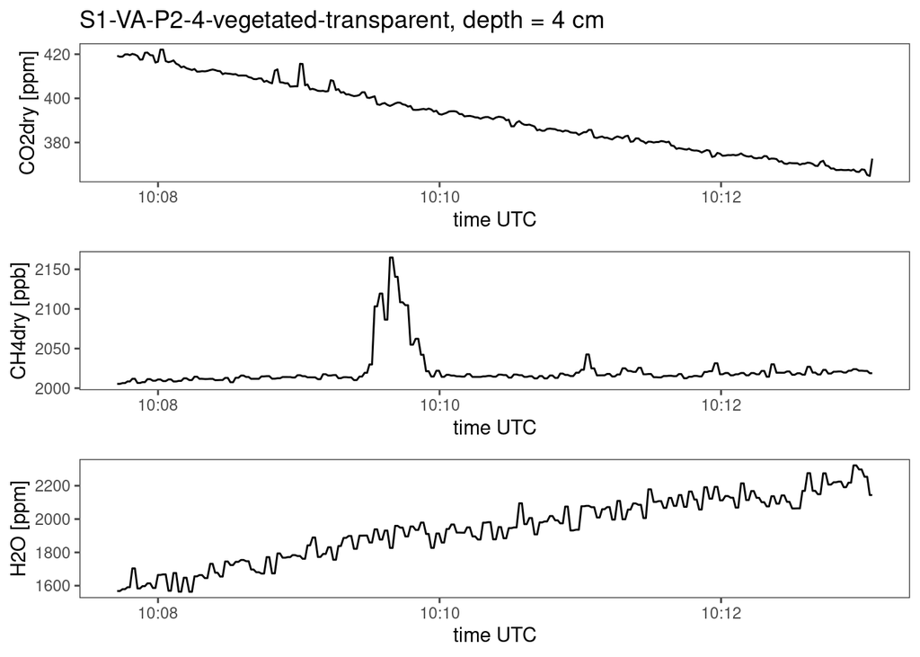

```r
# draw an incubation randomly among the ones available
draw <- sample(seq_along(auxfile$UniqueID), 1)

my_incub <- mydata[as.numeric(mydata$POSIX.time)> as.numeric(auxfile$start.time[draw]) &
                     as.numeric(mydata$POSIX.time)< as.numeric(auxfile$start.time[draw])+auxfile$duration[draw],]
my_incub <- my_incub[!is.na(my_incub$CO2dry_ppm),]

# visualizing it
plt_CO2 <- ggplot(my_incub, aes(POSIX.time, CO2dry_ppm))+geom_line()+
  theme_article()+
  xlab("time UTC")+
  ylab("CO2dry [ppm]")+
  ggtitle(paste0(auxfile$UniqueID, ", depth = ",corresp_fs$water_depth[incub], " cm"))
plt_CH4 <- ggplot(my_incub, aes(POSIX.time, CH4dry_ppb))+geom_line()+
  theme_article()+
  xlab("time UTC")+
  ylab("CH4dry [ppb]")
plt_H2O <- ggplot(my_incub, aes(POSIX.time, H2O_ppm))+geom_line()+
  theme_article()+
  xlab("time UTC")+
  ylab("H2O [ppm]")

plt <- ggarrange(plt_CO2, plt_CH4, plt_H2O, ncol = 1)
```

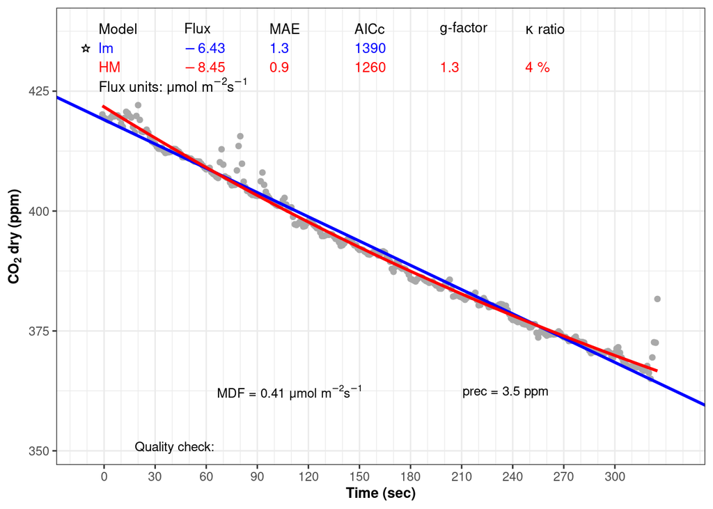

```r
# Define the measurements' window of observation
myauxfile <- auxfile[draw,]
mydata_ow <- obs.win(inputfile = mydata, auxfile = myauxfile,
                     obs.length = myauxfile$duration, shoulder = 2)
# Join mydata_ow with info on start end incubation
mydata_auto <- lapply(seq_along(mydata_ow), join_auxfile_with_data.loop, flux.unique = mydata_ow) %>%
  map_df(., ~as.data.frame(.x))

# Additional auxiliary data required for flux calculation.
mydata_auto <- mydata_auto %>%
  left_join(auxfile %>% select(UniqueID, Area, Vtot, Tcham, Pcham))
# Add instrument precision for each gas
prec = c(3.5, 0.6, 0.4, 45, 45)
mydata_auto <- mydata_auto %>%
  mutate(CO2_prec = prec[1], CH4_prec = prec[2], N2O_prec = prec[3],
         H2O_prec = prec[4])


# Calculate fluxes
CO2_results_auto <- goFlux(dataframe = mydata_auto, gastype = "CO2dry_ppm")
H2O_results_auto <- goFlux(mydata_auto, "H2O_ppm")
CH4_results_auto <- goFlux(mydata_auto, "CH4dry_ppb")
# Use best.flux to select the best flux estimates (LM or HM)
# based on a list of criteria
criteria <- c("g.factor", "kappa", "MDF", "R2", "SE.rel")

CO2_flux_res_auto <- best.flux(CO2_results_auto, criteria)
H2O_flux_res_auto <- best.flux(H2O_results_auto, criteria)
CH4_flux_res_auto <- best.flux(CH4_results_auto, criteria)


# Plots results
# Make a list of plots of all measurements, for each gastype
CO2_flux_plots <- flux.plot(CO2_flux_res_auto, mydata_auto, "CO2dry_ppm")
H2O_flux_plots <- flux.plot(H2O_flux_res_auto, mydata_auto, "H2O_ppm")
CH4_flux_plots <- flux.plot(CH4_flux_res_auto, mydata_auto, "CH4dry_ppb")

CO2_flux_plots
```

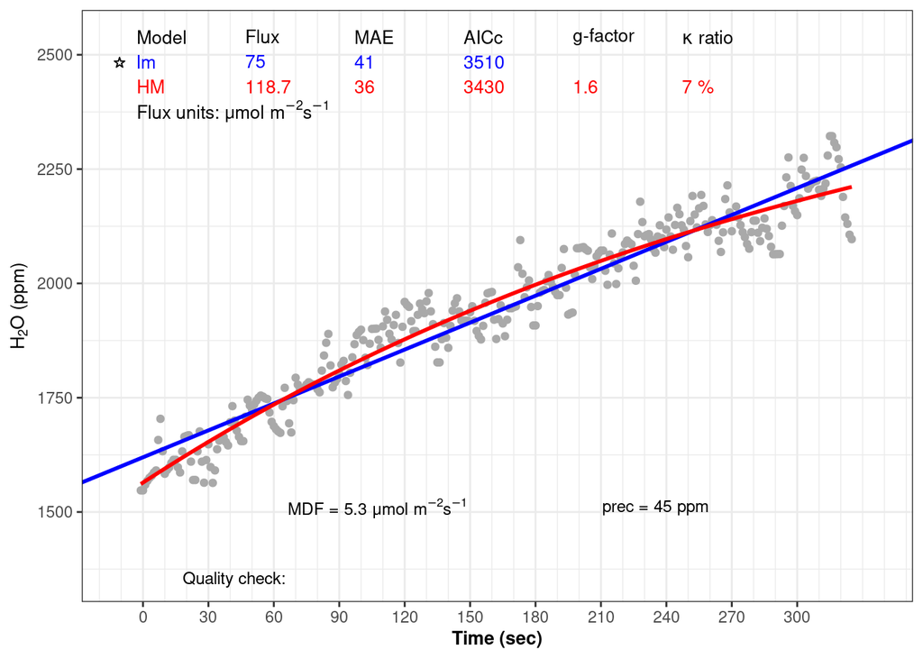

```r
H2O_flux_plots
```

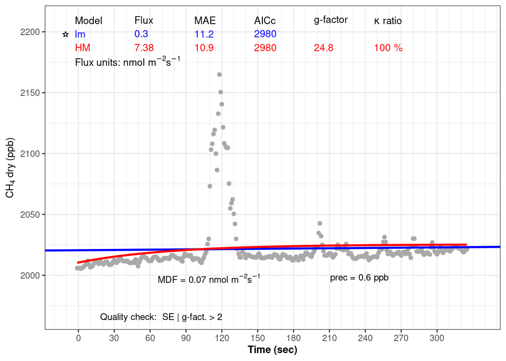

```r
CH4_flux_plots
```

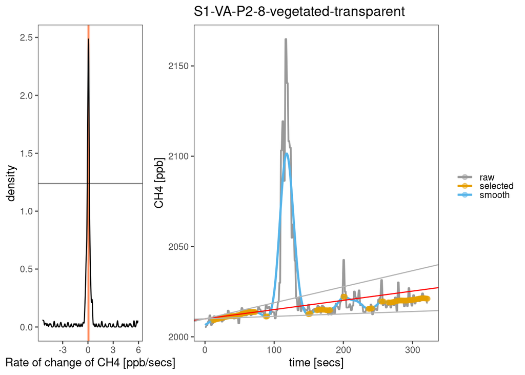

```r
# estimate ch4 diffusion and ebullition components
CH4_res_meth1 <- CH4_flux_res_auto
CH4_res_meth1$total_estimated <- NA
CH4_res_meth1$ebullition <- NA
CH4_res_meth1$diffusion <- NA

if(myauxfile$water_depth>0){
  # calling dedicated function
  df_ebull <- separate_ebullition_from_diffusion(my_incub = my_incub, UniqueID = myauxfile$UniqueID)
  # computing fluxes
  H2O_mol = my_incub$H2O_ppm / (1000*1000)
  myfluxterm <- flux.term(myauxfile$Vtot, myauxfile$Pcham, myauxfile$Area,
                          myauxfile$Tcham, first(H2O_mol))
  CH4_flux_total <- df_ebull$delta_ch4/df_ebull$duration*myfluxterm # nmol/m2/s
  CH4_flux_diff <- df_ebull$avg_diff_slope*myfluxterm # nmol/m2/s
  CH4_flux_ebull <- CH4_flux_total - CH4_flux_diff

  CH4_res_meth1$total_estimated <- CH4_flux_total
  CH4_res_meth1$ebullition <- CH4_flux_ebull
  CH4_res_meth1$diffusion <- CH4_flux_diff

} else {
  message("no water in this plot, methane is fully diffused, there is no bubbling")
  CH4_flux_total <- CH4_res_meth1$best.flux
  CH4_flux_ebull <- 0
  CH4_flux_diff <- CH4_res_meth1$best.flux
}
```

```r
CH4_res_meth1$total_estimated <- CH4_flux_total
  CH4_res_meth1$ebullition <- CH4_flux_ebull
  CH4_res_meth1$diffusion <- CH4_flux_diff

print(data.frame(CH4_flux_total = CH4_flux_total,
                 CH4_flux_diff = CH4_flux_diff,
                 CH4_flux_ebull = CH4_flux_ebull))
```

```
##   CH4_flux_total CH4_flux_diff CH4_flux_ebull
## 1       1.726383      1.951311     -0.2249275
```

# Running Analysis Across All Samples

## Re-doing the two last steps but for all incubations and across all subsites

In addition, flux estimates are saved

```r
# ---- Go through each incubation in fieldsheet and compute linear model for co2 and ch4 ----
subsites <- unique(fieldsheet$subsite)
isF_incub <- T
for (subsite in subsites){
  message("Now processing ",subsite)

  corresp_fs <- fieldsheet[fieldsheet$subsite == subsite,]
  gs <- first(corresp_fs$gas_analyzer)
  corresp_fs <- fieldsheet[fieldsheet$subsite == subsite,]
  corresp_fs$unix_start <- corresp_fs$unix_start_corrected
  corresp_fs$unix_stop <- corresp_fs$unix_stop_corrected
  corresp_fs <- corresp_fs[!is.na(corresp_fs$unix_start),]


  # read corresponding temperature logger file and keep initial temperature
  # --- Read corresponding Loggers data ----
  SN_logger_float <- first(corresp_fs$logger_floating_chamber)
  SN_logger_tube <- first(corresp_fs$logger_transparent_chamber)
  site_ID <- str_sub(subsite, start = 1, end = 5)

  # finding out if corresponding file exists, and its extension
  require(tools)
  dir_exists_loggdata <- dir.exists(paste0(loggerspath,"/",site_ID,"/"))
  if(dir_exists_loggdata){
    f <- list.files(paste0(loggerspath,"/",site_ID,"/"), full.names = T)
    r <- grep(pattern = ".hobo", x = f)
    if(length(r)>0){f <- f[-r]}
    r <- grep(pattern = ".txt", x = f)
    if(length(r)>0){f <- f[-r]}
    f_ext <- file_ext(f)
    i_f_float <- grep(pattern = SN_logger_float, x = f)[1]
    i_f_tube <- grep(pattern = SN_logger_tube, x = f)[1]
  }

  if(!is.na(SN_logger_float) & !is.na(i_f_float)){
    is_data_logger_float = T
    message("...reading corresponding temperature logger file for floating chamber")
    if(f_ext[i_f_float]=="xlsx"){
      data_logger_float <- readxl::read_xlsx(f[i_f_float],col_names = T)
    } else if(f_ext[i_f_float]=="csv"){
      data_logger_float <- read.csv(f[i_f_float], header = T)
    }
    data_logger_float <- data_logger_float[,seq(1,3)]
    names(data_logger_float) <- c("sn","datetime","temperature")
    data_logger_float$sn <- SN_logger_float
    if(is.character(data_logger_float$datetime)){
      data_logger_float$datetime <- as.POSIXct(data_logger_float$datetime, tz = 'utc', tryFormats = c("%m/%d/%y %r", "%d/%m/%Y %H:%M"))
    }
    data_logger_float$unixtime <- as.numeric(data_logger_float$datetime)
  } else {
    message("===> no data logger linked to the floating chamber!")
    is_data_logger_float = F}

  if(!is.na(SN_logger_tube) & !is.na(i_f_tube)){
    is_data_logger_tube = T
    message("...reading corresponding temperature logger file for tube chamber")
    if(f_ext[i_f_tube]=="xlsx"){
      data_logger_tube <- readxl::read_xlsx(f[i_f_tube],col_names = T)
    } else if(f_ext[i_f_tube]=="csv"){
      data_logger_tube <- read.csv(f[i_f_tube], header = T, fill = T)
    }
    data_logger_tube <- data_logger_tube[,seq(1,4)]
    names(data_logger_tube) <- c("sn","datetime","temperature","light")
    data_logger_tube$sn <- SN_logger_tube
    if(is.character(data_logger_tube$datetime)){
      if(length(grep(pattern = "AM", x = first(data_logger_tube$datetime)))>0 | length(grep(pattern = "PM", x = first(data_logger_tube$datetime)))>0){
        data_logger_tube$datetime <- as.POSIXct(data_logger_tube$datetime, tz = 'UTC', format = c("%m/%d/%y %r"))
      } else {
        data_logger_tube$datetime <- as.POSIXct(data_logger_tube$datetime, tz = 'UTC', format = "%m/%d/%Y %H:%M")
      }
    }
    data_logger_tube$unixtime <- as.numeric(data_logger_tube$datetime)
  } else {
    is_data_logger_tube = F
    message("===> no data logger linked to the tube chamber!")
  }


  path2data <- paste0(results_path,"/",subsite)
  if(dir.exists(path2data)){

    setwd(path2data)
    load(file = paste0("data_",subsite,".RData"))


    auxfile <- NULL

    for (incub in seq_along(corresp_fs$plot_id)){
      my_incub <- mydata[as.numeric(mydata$POSIX.time)> corresp_fs$unix_start[incub] &
                           as.numeric(mydata$POSIX.time)< corresp_fs$unix_stop[incub],]
      my_incub <- my_incub[!is.na(my_incub$CO2dry_ppm),]

      if (dim(my_incub)[1]>0){

        # Compute Temperature, Area and Volume from fieldsheet info
        myTemp <- 15 # a default temperature to run the flux calculation...
        if (corresp_fs$chamber_type[incub] == "floating"){
          if(is_data_logger_float){
            myTemp <- median(approx(data_logger_float$unixtime, data_logger_float$temperature, xout = as.numeric(my_incub$POSIX.time))$y )
          }
          myArea = 14365.4439 # cm2
          myVtot = 115/2 # L
        } else if (corresp_fs$chamber_type[incub] == "tube"){
          if(is_data_logger_tube){
            myTemp <- median(approx(data_logger_tube$unixtime, data_logger_tube$temperature, xout = as.numeric(my_incub$POSIX.time))$y )
          }
          myArea = pi*12.1**2 # cm2
          myVtot = myArea*as.numeric(corresp_fs$chamber_height_cm[incub])*1e-3 # L
        } else {
          warning("chamber type not correct!")
        }
        myPcham <- 100.1 #kPa

        # --- Create auxfile table ----
        # An auxfile table, made of fieldsheet, adding important variables. The auxfile
        # requires start.time and UniqueID.
        # start.time must be in the format "%Y-%m-%d %H:%M:%S"

        UniqueID = paste(subsite, seq_along(corresp_fs$pilot_site),corresp_fs$strata,corresp_fs$transparent_dark,sep = "-")[incub]

        auxfile_tmp <- data.frame(subsite = subsite,
                                  UniqueID = gsub(" ", "", UniqueID, fixed = TRUE),
                                  gas_analiser = gs,
                                  start.time = as.POSIXct((corresp_fs$unix_start[incub]), tz = "UTC"),
                                  duration = (corresp_fs$unix_stop[incub]) - (corresp_fs$unix_start[incub]),
                                  water_depth = corresp_fs$water_depth[incub],
                                  Area = myArea,
                                  Vtot = myVtot,
                                  Tcham = myTemp,
                                  Pcham = myPcham,
                                  strata = corresp_fs$strata[incub],
                                  chamberType = corresp_fs$chamber_type[incub],
                                  lightCondition = corresp_fs$transparent_dark[incub])
        if(is.null(auxfile)){
          auxfile <- auxfile_tmp
        } else {
          auxfile <- rbind(auxfile, auxfile_tmp)
        }

      }
    }

    # draw a few incubations randomly
    # draw <- sample(seq_along(auxfile$subsite), 3)

    # Define the measurements' window of observation
    auxfile <- auxfile
    mydata_ow <- obs.win(inputfile = mydata, auxfile = auxfile,
                         obs.length = auxfile$duration, shoulder = 2)

    # Join mydata_ow with info on start end incubation
    mydata_auto <- lapply(seq_along(mydata_ow), join_auxfile_with_data.loop, flux.unique = mydata_ow) %>%
      map_df(., ~as.data.frame(.x))

    # Additional auxiliary data required for flux calculation.
    mydata_auto <- mydata_auto %>%
      left_join(auxfile %>% select(UniqueID, Area, Vtot, Tcham, Pcham))

    # Add instrument precision for each gas
    prec = c(3.5, 0.6, 0.4, 45, 45)
    mydata_auto <- mydata_auto %>%
      mutate(CO2_prec = prec[1], CH4_prec = prec[2], N2O_prec = prec[3],
             H2O_prec = prec[4])

    # Calculate fluxes
    CO2_results_auto <- goFlux(dataframe = mydata_auto, gastype = "CO2dry_ppm")
    H2O_results_auto <- goFlux(mydata_auto, "H2O_ppm")
    CH4_results_auto <- goFlux(mydata_auto, "CH4dry_ppb")

    # Use best.flux to select the best flux estimates (LM or HM)
    # based on a list of criteria
    criteria <- c("g.factor", "kappa", "MDF", "R2", "SE.rel")

    CO2_flux_res_auto <- best.flux(CO2_results_auto, criteria)
    H2O_flux_res_auto <- best.flux(H2O_results_auto, criteria)
    CH4_flux_res_auto <- best.flux(CH4_results_auto, criteria)

    # Plots results
    # Make a list of plots of all measurements, for each gastype
    CO2_flux_plots <- flux.plot(CO2_flux_res_auto, mydata_auto, "CO2dry_ppm")
    H2O_flux_plots <- flux.plot(H2O_flux_res_auto, mydata_auto, "H2O_ppm")
    CH4_flux_plots <- flux.plot(CH4_flux_res_auto, mydata_auto, "CH4dry_ppb")

    # estimate ch4 diffusion and ebullition components---------| METHOD 1 |-----------
    CH4_res_meth1 <- CH4_flux_res_auto
    CH4_res_meth1$total_estimated <- NA
    CH4_res_meth1$ebullition <- NA
    CH4_res_meth1$diffusion <- NA


    for (i in seq_along(auxfile)){
      if(auxfile$water_depth[i]>0){
        my_incub <- mydata[as.numeric(mydata$POSIX.time)> auxfile$start.time[i] &
                             as.numeric(mydata$POSIX.time)< auxfile$start.time[i]+auxfile$duration[i],]
        my_incub <- my_incub[!is.na(my_incub$CO2dry_ppm),]
        # calling dedicated function
        df_ebull <- separate_ebullition_from_diffusion(my_incub = my_incub, UniqueID = auxfile$UniqueID[i])
        # computing fluxes
        H2O_mol = my_incub$H2O_ppm / (1000*1000)
        myfluxterm <- flux.term(auxfile$Vtot[i], auxfile$Pcham[i], auxfile$Area[i],
                                auxfile$Tcham[i], first(H2O_mol))
        CH4_flux_total <- df_ebull$delta_ch4/df_ebull$duration*myfluxterm # nmol/m2/s
        CH4_flux_diff <- df_ebull$avg_diff_slope*myfluxterm # nmol/m2/s
        CH4_flux_ebull <- CH4_flux_total - CH4_flux_diff
      } else {
        CH4_flux_total <- CH4_flux_ebull <- CH4_res_meth1$best.flux[which(CH4_res_meth1$UniqueID==auxfile$UniqueID[i])]
        CH4_flux_ebull <- 0
      }
      CH4_res_meth1$total_estimated[which(CH4_res_meth1$UniqueID==auxfile$UniqueID[i])] <- CH4_flux_total
      CH4_res_meth1$ebullition[which(CH4_res_meth1$UniqueID==auxfile$UniqueID[i])] <- CH4_flux_ebull
      CH4_res_meth1$diffusion[which(CH4_res_meth1$UniqueID==auxfile$UniqueID[i])] <- CH4_flux_diff
    }


    setwd(path2data)
    write.csv(x = CO2_flux_res_auto, file = paste0(subsite,"_co2_fluxes.csv"), row.names = F)
    write.csv(x = CH4_res_meth1, file = paste0(subsite,"_ch4_fluxes.csv"), row.names = F)


    # Combine plot lists into one list
    flux_plot.ls <- c(CO2_flux_plots, CH4_flux_plots, H2O_flux_plots)

    # Save plots to pdf
    setwd(plots_path)
    myfilename <- paste(subsite, as.character(as.Date(first(auxfile$start.time))),sep="_")
    # myfilename <- gsub("-","", myfilename)
    flux2pdf(flux_plot.ls, outfile = paste0(plots_path,"/",myfilename,".pdf"))


  } # closing if(dir.exists(path2data)){
}
```

```r
table_results <- auxfile %>%
  left_join(CO2_flux_res_auto %>% select(UniqueID, best.flux, model, quality.check)) %>%
  rename(CO2_flux = best.flux, CO2_model = model, CO2_quality.check = quality.check) %>%
  left_join(CH4_res_meth1 %>% select(UniqueID, best.flux, model, quality.check)) %>%
  rename(CH4_diffusive_flux = best.flux, CH4_model = model, CH4_quality.check = quality.check)
```

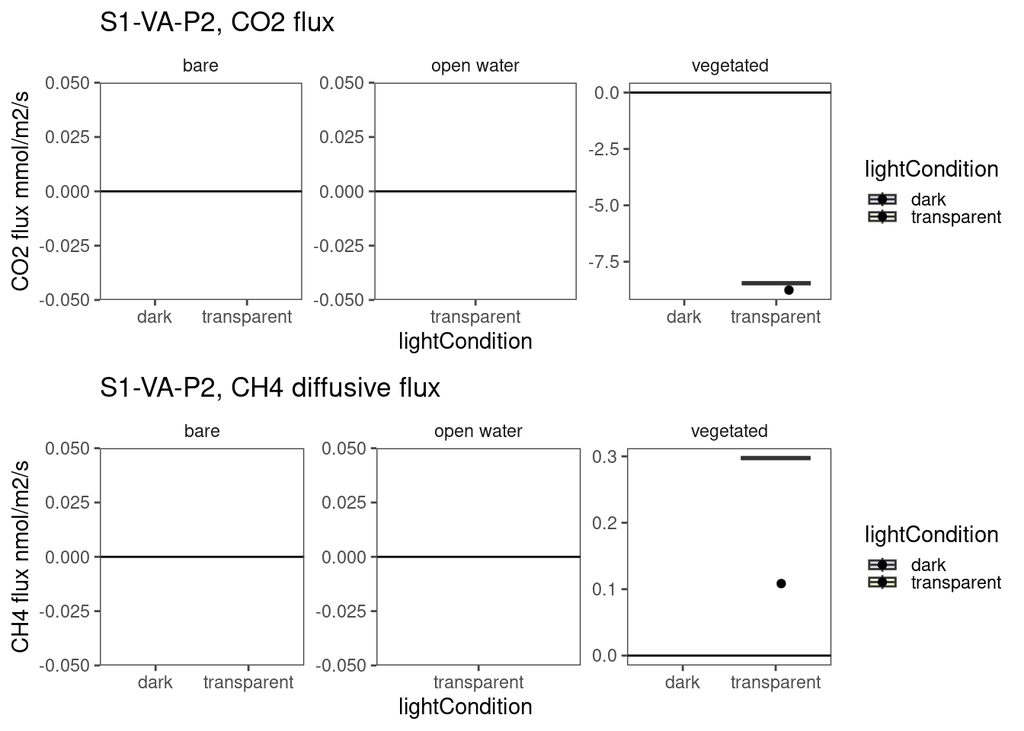

```r
plt_CO2 <- ggplot(table_results, aes(lightCondition, CO2_flux, fill = lightCondition))+
  geom_hline(yintercept = 0)+
  geom_boxplot(alpha=0.2)+geom_jitter(width = 0.2)+
  theme_article()+facet_wrap(.~strata, scales = "free")+
  ylab("CO2 flux mmol/m2/s")+
  ggtitle(paste0(subsite,", CO2 flux"))+
  scale_fill_viridis_d(begin = 0.2, end = 0.9)


plt_CH4diff <- ggplot(table_results, aes(lightCondition, CH4_diffusive_flux, fill = lightCondition))+
  geom_hline(yintercept = 0)+
  geom_boxplot(alpha=0.2)+geom_jitter(width = 0.2)+
  theme_article()+facet_wrap(.~strata, scales = "free")+
  ylab("CH4 flux nmol/m2/s")+
  ggtitle(paste0(subsite,", CH4 diffusive flux"))+
  scale_fill_viridis_d(begin = 0.2, end = 0.9)



ggarrange(plt_CO2, plt_CH4diff, ncol = 1)
```